# REBCA Housing Anlaysis

## Project: REBCA Housing Analysis

**A project by your favorite Data Scientist**

- *Surohit Tandon*

Table of Contents:

- Task 0:
  - Loading in the Data
  - Data Exploration (EDA)
- Task 1:
  - Data Cleaning/Preprocessing
- Task 2:
  - Measures of Central Tendency
- Task 3:
  - Visualisations
  - Normalization
- Task 4:
  - Seperating Data
- Task 5:
  - Model Creation and Testing
- Task 6:
- Conclusion

### Introduction

Each required tasked is linked to the contents above. wherever I make a decision or add beyond the outlined tasks, I will do my best to clearly state any assumptions I made and give the best reasoning possible. During the creation of this notebook many sections were iteratively reviewed. Keeping this in mind, I have organised it such that it should be easy to follow.

Now, lets get to the fun stuff!

## Task 0:

### Loading in the Data

This section includes the basic loading phase of our training and testing data.

```python
# Importing basic libraries for data analytics/science
import numpy as np
import pandas as pd
from scipy import stats
from scipy.stats import norm
import math

# Import sklearn.preprocessing.StandardScaler for feature scaling
from sklearn.preprocessing import MinMaxScaler

# Libraries for visualisations
import matplotlib.pyplot as plt
import seaborn as sns
from mpl_toolkits import mplot3d
%matplotlib inline

# Traditional Supervised Regression model Imports
from sklearn.svm import SVR
from sklearn.ensemble import GradientBoostingRegressor
from sklearn.tree import DecisionTreeRegressor

# Used to score our regression models
from sklearn.metrics import mean_absolute_error
from sklearn.metrics import make_scorer
from sklearn.model_selection import GridSearchCV

#Keras NN library
from keras.models import Sequential
from keras.layers import Dense, Activation, Flatten
from keras.callbacks import ModelCheckpoint
```

```python
# Using Pandas to import the data
data = pd.read_csv('fun_data.csv')
```

```python
# Checking the data was correctly imported
data.head()
```

|  | listing_type | tenant_rating | bedrooms | bathrooms | monthly_rent |
| --- | --- | --- | --- | --- | --- |
| 0 | Entire home/apt | 5.0 | 4 | 2.5 | 2500 |
| 1 | Entire home/apt | NaN | 2 | 1.0 | 1000 |
| 2 | Private room | 4.5 | 1 | 1.0 | 820 |
| 3 | Entire home/apt | 5.0 | 0 | 1.0 | 490 |
| 4 | Entire home/apt | 4.5 | 1 | 1.0 | 900 |

```python
# Checking the data was correctly imported
data.tail()
```

|  | listing_type | tenant_rating | bedrooms | bathrooms | monthly_rent |
| --- | --- | --- | --- | --- | --- |
| 7571 | Entire home/apt | NaN | 1 | 1.0 | 780 |
| 7572 | Private room | NaN | 1 | 1.0 | 340 |
| 7573 | Entire home/apt | NaN | 1 | 1.0 | 800 |
| 7574 | Entire home/apt | NaN | 2 | 2.0 | 1290 |
| 7575 | Entire home/apt | NaN | 1 | 1.0 | 1510 |

### Data Exploration (EDA)

Great! The load in went swimmingly. Now to explore our features and pick out any unusual patterns.

```python
# Checking the dimensions of our data set
print("We have {} rows and {} columns".format(data.shape[0],data.shape[1]))
```

```
We have 7576 rows and 5 columns
```

```python
# Checking the number of values in each distinct category in listing_type
print(data.listing_type.value_counts(dropna=False))
```

```
Entire home/apt    5603
Private room       1844
Shared room         129
Name: listing_type, dtype: int64
```

```python
# Having a look at all the number of NaN values contained in each column
data.isna().sum()
```

```
listing_type        0
tenant_rating    1473
bedrooms            0
bathrooms           2
monthly_rent        0
dtype: int64
```

## Task 1:

### Cleaning/Preprocessing

1. We need to address the missing values in tenant_rating.
2. Adress the missing values in bathrooms.
3. All characters in listing_type need to be lower case

```python
# Returning a boolean array of missing rows.
(data.isna().sum(axis=1)==0).head()
```

```
0     True
1    False
2     True
3     True
4     True
dtype: bool
```

```python
# Storing the boolean array
drop_array = data.isna().sum(axis=1)==0
```

```python
# Ensuring array was correctly stored
drop_array.head()
```

```
0     True
1    False
2     True
3     True
4     True
dtype: bool
```

```python
# Checking the number of rows we are to drop
print("We need to drop {} rows".format(len(drop_array) - sum(drop_array)))
```

```
We need to drop 1475 rows
```

```python
# Passing the array through our pandas dataframe to return True rows
clean_data = data[drop_array].copy()
```

```python
# Ensuring we have the correct size dataframe
assert data.shape[0] - clean_data.shape[0] == 1475
print("If you're seeing this then we did a good job cap'n")
```

```
If you're seeing this then we did a good job cap'n
```

```python
# Lowering the case of all listing_type strings
clean_data.listing_type = clean_data.listing_type.str.lower()
```

```python
# Showing the first 25 samples
clean_data.head(n=25)
```

|  | listing_type | tenant_rating | bedrooms | bathrooms | monthly_rent |
| --- | --- | --- | --- | --- | --- |
| 0 | entire home/apt | 5.0 | 4 | 2.5 | 2500 |
| 2 | private room | 4.5 | 1 | 1.0 | 820 |
| 3 | entire home/apt | 5.0 | 0 | 1.0 | 490 |
| 4 | entire home/apt | 4.5 | 1 | 1.0 | 900 |
| 5 | private room | 4.5 | 1 | 3.0 | 650 |
| 6 | private room | 5.0 | 1 | 1.0 | 780 |
| 7 | entire home/apt | 5.0 | 2 | 1.0 | 1650 |
| 8 | entire home/apt | 5.0 | 2 | 1.0 | 950 |
| 9 | entire home/apt | 4.5 | 1 | 1.0 | 1150 |
| 10 | entire home/apt | 5.0 | 2 | 1.0 | 1350 |
| 11 | private room | 4.5 | 0 | 1.5 | 500 |
| 13 | private room | 5.0 | 1 | 1.0 | 1090 |
| 14 | entire home/apt | 5.0 | 3 | 2.0 | 2500 |
| 15 | private room | 4.5 | 1 | 1.5 | 370 |
| 16 | private room | 4.5 | 3 | 1.5 | 500 |
| 17 | private room | 4.5 | 1 | 1.0 | 1000 |
| 18 | entire home/apt | 5.0 | 0 | 1.0 | 720 |
| 19 | entire home/apt | 4.5 | 1 | 1.0 | 600 |
| 20 | entire home/apt | 5.0 | 1 | 1.0 | 1400 |
| 21 | entire home/apt | 4.5 | 2 | 1.0 | 990 |
| 22 | entire home/apt | 5.0 | 1 | 1.0 | 590 |
| 23 | private room | 5.0 | 1 | 1.0 | 450 |
| 24 | entire home/apt | 5.0 | 1 | 1.0 | 770 |
| 25 | entire home/apt | 4.0 | 3 | 2.0 | 1800 |
| 26 | private room | 5.0 | 1 | 1.0 | 750 |

```python
# Checking the rating distribution
clean_data.tenant_rating.value_counts()
```

```
5.0    4410
4.5    1501
4.0     141
3.5      44
3.0       4
2.5       1
Name: tenant_rating, dtype: int64
```

## Task 2:

### Measures of Central Tendency

Here we are going to do the following:

1. Print the average tenant_rating and monthly_rent from all samples
2. Print the average monthly_rent for listing_type *private room*
3. Print the average tenant_rating for listing_type *entire home/apt*
4. Print the IQR for monthly_rent from all samples
5. Print the mode for bedrooms and bathrooms
- **Note**: Everything was printed to 2 decimal places (arbitrarily)

```python
# 1. Printing the average tenant_rating and monthly_rent
print("We have an average monthly rent of \033[1m${:.2f}\033[0m \n".format(clean_data.monthly_rent.mean()))
print("And we have an average rating of \033[1m{:.2f}\n".format(clean_data.tenant_rating.mean()))
```

```
We have an average monthly rent of $1073.35

And we have an average rating of 4.84
```

```python
# 2. Printing Average monthly_rent for listing_type private room
private_monthly_rent_avg = clean_data[clean_data.listing_type == 'private room'].monthly_rent.mean()
print("We have an average monthly rent of \033[1m${:.2f}\033[0m for private rooms".format(private_monthly_rent_avg))
```

```
We have an average monthly rent of $617.29 for private rooms
```

```python
# 3. Average Tenant_rating for listing type of entire home/apt
entire_tenant_rating_avg = clean_data[clean_data.listing_type == 'entire home/apt'].tenant_rating.mean()
print("We have an Average Tenant_rating of \033[1m{:.2f}\033[0m for an entire home/apt".format(entire_tenant_rating_avg))
```

```
We have an Average Tenant_rating of 4.84 for an entire home/apt
```

```python
# 4. Printing the IQR for monthly rent across all samples
month_rent_IQR = np.quantile(clean_data.monthly_rent, 0.75) - np.quantile(clean_data.monthly_rent, 0.25)
print("The IQR for monthly rent is \033[1m${:.2f}\033[0m across all samples".format(month_rent_IQR))
```

```
The IQR for monthly rent is $630.00 across all samples
```

**Note**: IQR is only really a useful measure of spread when considering a somewhat normally distributed variable

```python
# 5. Mode number of bedrooms and bathrooms
num_beds = stats.mode(clean_data.bedrooms)[0][0]
num_baths = stats.mode(clean_data.bathrooms)[0][0]

print("The mode number of beds is \033[1m{}\033[0m across all samples".format(num_beds))
print("The mode number of bathrooms is \033[1m{}\033[0m across all samples".format(int(num_baths)))
```

```
The mode number of beds is 1 across all samples
The mode number of bathrooms is 1 across all samples
```

## Task 3:

[interactive chart not shown]

### Visualisations

Here we are going to:

1. Generate a box and whisker plot for listing_type “private room” where bedrooms are equal to 1. Label the upper extreme, upper quartile, median, lower quartile, and lower extreme (with their values)
2. Are there any outliers? If there is, generate a table displaying some information of your choosing about the outliers.
3. For listing_type “private room” and “entire home/apt”, generate a plot with tenant_rating on the y-axis and monthly_rent on the x-axis. Give each plot a name and don’t forget to label the axes.
4. Generate a plot for listing_type “entire home/apt” with tenant_rating on the x-axis, bedrooms on the y-axis, and monthly_rent on the z-axis.
- Since each of these visualisations are a little more involved I shall break down each problem into a series of steps.
- Assuming "Upper and Lower Extreme" are refferencing Lower and Upper inner fence.

```python
# 1. Querying all data with private room
private_room_data = clean_data[clean_data.listing_type == 'private room'].copy()
```

```python
# 1. Second query for 1 bedroom
private_1_bed_data = private_room_data[private_room_data.bedrooms == 1].copy()
```

```python
# 1. Taking a quick look that we queried the right data
private_1_bed_data.head()
```

|  | listing_type | tenant_rating | bedrooms | bathrooms | monthly_rent |
| --- | --- | --- | --- | --- | --- |
| 2 | private room | 4.5 | 1 | 1.0 | 820 |
| 5 | private room | 4.5 | 1 | 3.0 | 650 |
| 6 | private room | 5.0 | 1 | 1.0 | 780 |
| 13 | private room | 5.0 | 1 | 1.0 | 1090 |
| 15 | private room | 4.5 | 1 | 1.5 | 370 |

```python
def plot_box(data, label):
    '''
    INPUT:
    data - (object) Continuous array of ordinal data
    label - (str) Label for y-axis and title

    OUTPUT:
    plt - Box and Whisker plot of the feature

    Description:
    Returns a Box and Whisker plot of the data and passes a visualisation as well as the mean and standard deviation.
    '''
    # Calculating spread measures
    median = np.quantile(data[i], 0.5)
    lower_quart = np.quantile(data[i], 0.25)
    upper_quart = np.quantile(data[i], 0.75)
    IQR = upper_quart - lower_quart
    upper_fence = upper_quart + 1.5*IQR
    lower_fence = lower_quart - 1.5*IQR

    # Creating plotting object
    sns.boxplot(y=i,
            orient="h", data= data,)
    plt.grid(True)
    plt.title('Box and whisker plot of {}:'.format(label))
    plt.xlabel('{}'.format(label));

    # Adding the markers
    plt.axvline(median, label = 'Median = {}'.format(median), color = 'black')
    plt.axvline(lower_quart, label = 'Lower Quartile = {}'.format(lower_quart), color = 'purple')
    plt.axvline(upper_quart, label = 'Upper Quartile = {}'.format(upper_quart) , color = 'blue')
    plt.axvline(upper_fence, label = 'Upper Inner Fence = {}'.format(upper_fence), color = 'orange')
    plt.axvline(lower_fence, label = 'Lower Inner Fence = {}'.format(lower_fence), color = 'red')

    plt.legend(loc='upper right' , bbox_to_anchor=(1.45, 0.8), shadow=True, ncol=1)

    return plt
```

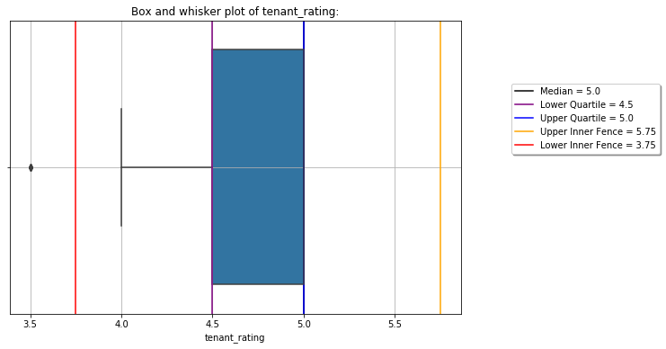

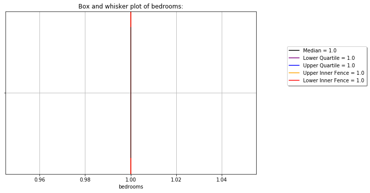

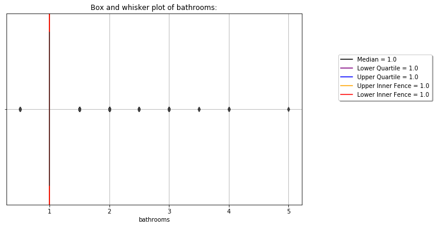

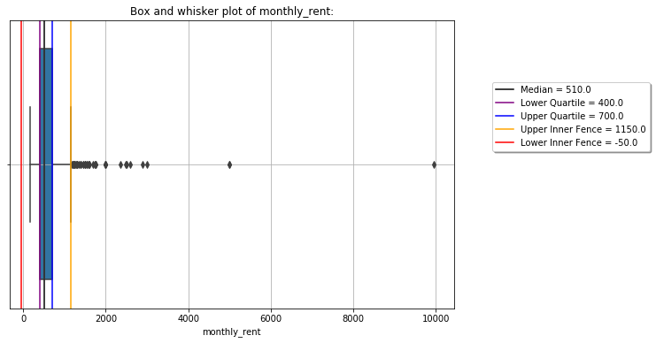

```python
# 1. Iterating through our columns and printing a boxplot for each feature
# NOTE: Click on the left of the output box to expand the output into the whole notebook
for i in list(private_1_bed_data.columns[1:]):
    fig, ax= plt.subplots()
    fig.set_size_inches(9, 6)
    plt.subplot(1,1,1)
    plot_box(private_1_bed_data, i)
    plt.show()
```

```python
# Function used to create histogram plots
def plot_hist(data, label):
    from scipy.stats import norm
    import scipy
    '''
    INPUT:
    data - (int) Continuous array of data
    label - (str) Label for x-axis and title

    OUTPUT:
    plt - Histogram
    mu - Mean of the array
    sigma - Standard deviation of the array



    Description:
    Computes the histogram of the data and passes a visualisation as well as the mean and standard deviation.
    '''


    # best fit of data
    (mu, sigma) = norm.fit(data)

    n, bins, patches = plt.hist(data, 20, density=1, facecolor='green', alpha=0.75)
    y = scipy.stats.norm.pdf( bins, mu, sigma)
    plt.plot(bins, y, 'r--', linewidth=2)
    plt.grid(True)
    plt.axvline(mu, label = 'Mean', color = 'black')
    plt.axvline(np.median(data), label = "Median", color = 'orange')
    plt.xlabel('{}'.format(label))
    plt.ylabel('Frequency')
    plt.title('Histogram of {}: $\mu = {:.3}$, $\sigma = {:.3}$'.format(label, mu, sigma))
    plt.grid(True)
    plt.legend()

    return plt, mu, sigma
```

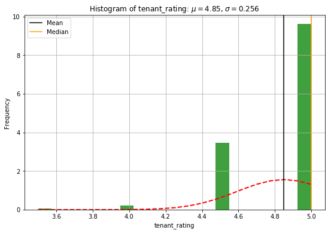

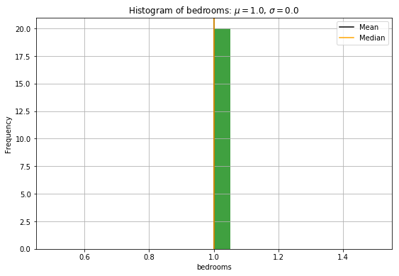

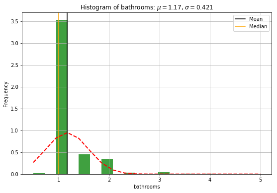

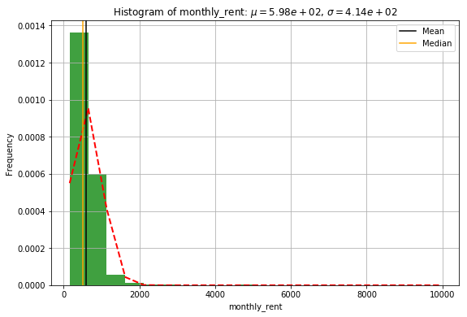

```python
# Looping through all columns and plotting a histogram with a normal curve approximated
for i in list(private_1_bed_data.columns[1:]):
    fig, ax= plt.subplots()
    fig.set_size_inches(9, 6)
    plt.subplot(1,1,1)
    plot_hist(private_1_bed_data[i], i)
    plt.show()
```

##### Observations:

- Both sets of visualisations indicate that the monthly_rent feature is severely skewed with many outliers.
- We can ignore the outliers present in the bathrooms feature simply due to the fact that the data is exceedingly concentrated around the median.
- tenant_rating also seems to have some outliers present that may be worth investigating.

```python
# 2. Find the quantiles for monthly rent
q75, q25 = np.quantile(private_1_bed_data.monthly_rent, [0.75,0.25])

iqr = q75 - q25

lower_fence = q25 - (iqr*1.5)
upper_fence = q75 + (iqr*1.5)
```

```python
# 2. Storing the data in a numpy array
monthly_rent_col = private_1_bed_data.monthly_rent.copy()
```

```python
# 2. Gathering all the outlier points
month_rent_outliers = []
for i in monthly_rent_col:
    if i>upper_fence or i<lower_fence:
        month_rent_outliers.append(i)
```

```python
# 2. Finding the quantiles for tenant rating
t_q75, t_q25 = np.quantile(private_1_bed_data.tenant_rating, [0.75,0.25])

t_iqr = t_q75 - t_q25

t_lower_fence = t_q25 - (t_iqr*1.5)
t_upper_fence = t_q75 + (t_iqr*1.5)
```

```python
# 2. Storing the data in a numpy array
tenant_rat_col = private_1_bed_data.tenant_rating.copy()
```

```python
# 2. Gathering all the outlier points for tenant ratings
ten_rat_outliers = []
for i in tenant_rat_col:
    if i>t_upper_fence or i<t_lower_fence:
        ten_rat_outliers.append(i)
```

```python
# 2. Creating our empty table
indexs = ['Number of Outliers', 'Median', 'Max', 'Min']
cols = ['tenant_ratings','monthly_rent']
outlier_df = pd.DataFrame(index=indexs, columns = cols)
```

```python
# 2. Storing some values
tenant_vals = len(ten_rat_outliers), np.median(ten_rat_outliers), max(ten_rat_outliers), min(ten_rat_outliers)
monthly_vals = len(month_rent_outliers), np.median(month_rent_outliers), max(month_rent_outliers), min(month_rent_outliers)
```

```python
# 2. transfering our arrays to our table
outlier_df.tenant_ratings = tenant_vals
outlier_df.monthly_rent = monthly_vals
```

```python
# 2. Displaying the table
outlier_df
```

|  | tenant_ratings | monthly_rent |
| --- | --- | --- |
| Number of Outliers | 5.0 | 52.0 |
| Median | 3.5 | 1450.0 |
| Max | 3.5 | 9950.0 |
| Min | 3.5 | 1190.0 |

1. For listing_type “private room” and “entire home/apt”, generate a plot with tenant_rating on the y-axis and monthly_rent on the x-axis. Give each plot a name and don’t forget to label the axes.

```python
# 3. querying our dataset
scatter_data = clean_data[clean_data.listing_type != 'shared room'].copy()
```

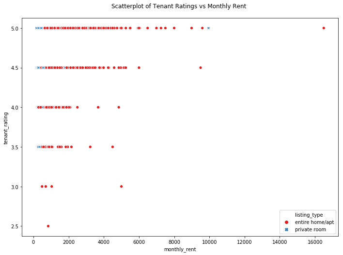

```python
# 3. A quick visual
fig, ax = plt.subplots()
fig.set_size_inches(11.7, 8.27)
sns.scatterplot(x='monthly_rent', y='tenant_rating',
                hue="listing_type",style="listing_type", palette="Set1",
                data = scatter_data)
plt.title('Scatterplot of Tenant Ratings vs Monthly Rent \n');
```

- So we have an ordinal y axis and a continous x axis. Seems like it would be best to create a box and whisker plot once again across the tenant ratings for both entire home/apt and private room.

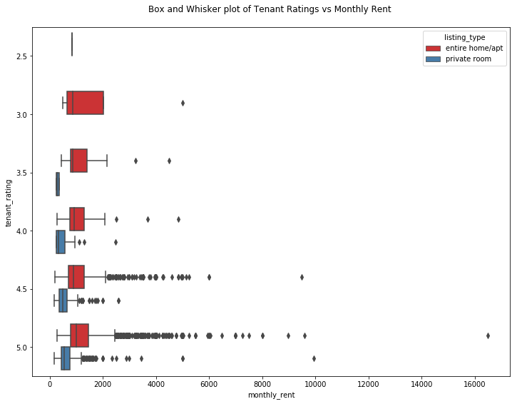

```python
# 3. New visual using Box plots
# NOTE: the y axis is inverted compared to the above plot
fig, ax = plt.subplots()
fig.set_size_inches(12, 9)
sns.boxplot(x="monthly_rent", y="tenant_rating",
            orient="h", data=scatter_data,
            hue = 'listing_type' , palette="Set1")
plt.title('Box and Whisker plot of Tenant Ratings vs Monthly Rent \n');
```

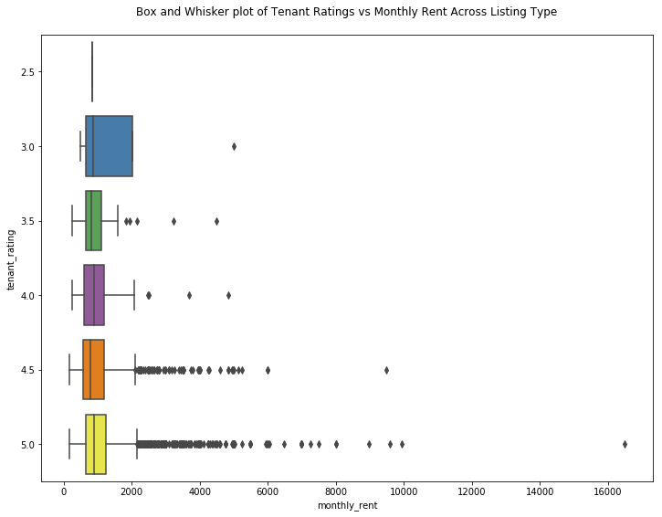

```python
# 3. New visual using Box plots
fig, ax = plt.subplots()
fig.set_size_inches(12, 9)
sns.boxplot(x="monthly_rent", y="tenant_rating",
            orient="h", data=scatter_data,
             palette="Set1")
plt.title('Box and Whisker plot of Tenant Ratings vs Monthly Rent Across Listing Type\n');
```

- A violin plot plays a similar role as a box and whisker plot. It shows the distribution of quantitative data across several levels of one (or more) categorical variables such that those distributions can be compared. Unlike a box plot, in which all of the plot components correspond to actual datapoints, the violin plot features a kernel density estimation of the underlying distribution.
- For visual purposes I much prefor the Violin plot.

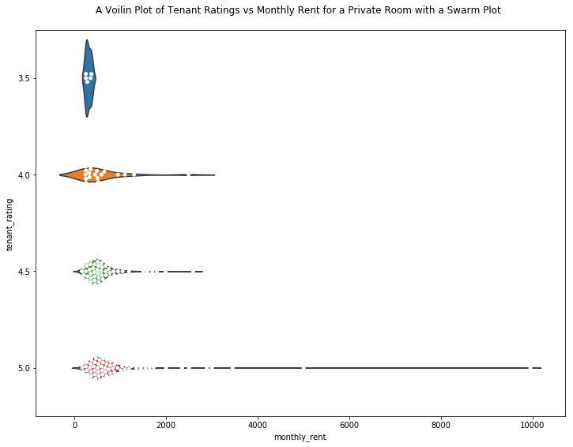

```python
# Violin/Swarm plot for a Private Room
fig = plt.figure()
fig.set_size_inches(12, 9)
sns.violinplot(x="monthly_rent", y="tenant_rating", data=scatter_data[scatter_data.listing_type != 'entire home/apt'],
               orient="h", inner=None)
sns.swarmplot(x="monthly_rent", y="tenant_rating",
            orient="h", data=scatter_data[scatter_data.listing_type != 'entire home/apt'],
            color="white", edgecolor="gray")
plt.title('A Voilin Plot of Tenant Ratings vs Monthly Rent for a Private Room with a Swarm Plot \n');
```

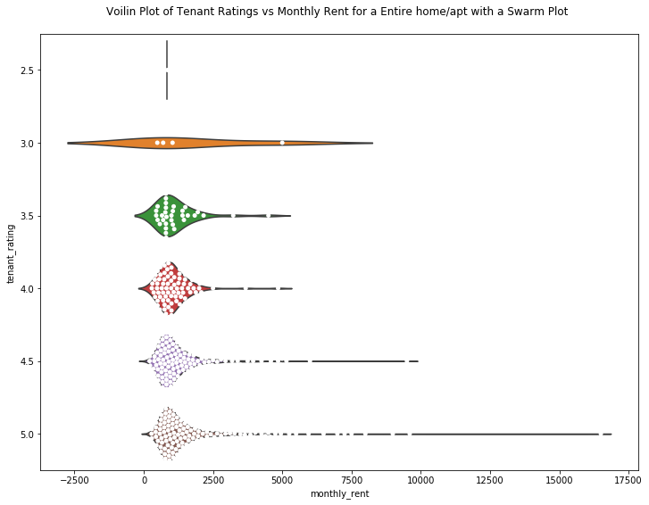

```python
# Violin/Swarm plot for a Entire Home/Apt
fig, ax = plt.subplots()
fig.set_size_inches(12, 9)
sns.violinplot(x="monthly_rent", y="tenant_rating", data=scatter_data[scatter_data.listing_type != 'private room'],
               orient="h", inner=None)
sns.swarmplot(x="monthly_rent", y="tenant_rating",
            orient="h", data=scatter_data[scatter_data.listing_type != 'private room'],
            color="white", edgecolor="gray")
plt.title('Voilin Plot of Tenant Ratings vs Monthly Rent for a Entire home/apt with a Swarm Plot \n');
```

While the above tenant rating of 3 may look concerning, it is important to note that the tail crosses the 0 mark due to the fact it has a large distribution with so few points and that the majority of its points are centered around the 0 mark.

All of the above plots indicate that there seems to be a higher likelihood of an increase in spread in terms of monthly rent tailing off to the right when considering an increase in tenant ratings. This indicates that there is a higher chance that if the rating is high, the monthly rent is harder to predict as it may be (somewhat randomly) a high value. This results in a positive skew for almost all of the tenant ratings across both homes/apts and private rooms.

Generating a plot for listing_type “entire home/apt” with tenant_rating on the x-axis, bedrooms on the y-axis, and monthly_rent on the z-axis.

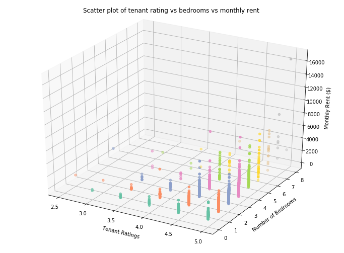

```python
# plot for listing_type “entire home/apt” with tenant_rating on the x-axis,
# bedrooms on the y-axis, and monthly_rent on the z-axis
fig = plt.figure()
fig.set_size_inches(12, 9)
ax = fig.add_subplot(111, projection='3d')
x = clean_data[clean_data['listing_type'] == 'entire home/apt'].tenant_rating
y = clean_data[clean_data['listing_type'] == 'entire home/apt'].bedrooms
z = clean_data[clean_data['listing_type'] == 'entire home/apt'].monthly_rent


ax.scatter(x, y, z, c=y, cmap='Set2')
plt.title('Scatter plot of tenant rating vs bedrooms vs monthly rent \n')
ax.set_xlabel('\n Tenant Ratings')
ax.set_ylabel('\n Number of Bedrooms')
ax.set_zlabel('\n Monthly Rent ($)');
```

### Normalization and One Hot Encoding

One step I have decided to include is the normalization/scaling of our input features. This will help our model avoid large attribute values from causing any numerical problems during our model training. This [blog](https://medium.com/@urvashilluniya/why-data-normalization-is-necessary-for-machine-learning-models-681b65a05029) and this paper help explain the phenomenon.

Applying a scaling to the data does not change the shape of each feature's distribution however, normalization ensures that each feature is treated equally when applying supervised learners. Note that once scaling is applied, observing the data in its raw form will no longer have the same original meaning. Note, we **do not want to transform our target feature**.

Also, we may have considered using a log-transform on our inputs if we had a distribution where there were a a number of non-trivial outliers. However, in our case, the visualisations indicate this shouldn't be a large worry. We may review removing the outliers as an option to model improvement.

Secondly, I will need to one hot encode the listing_type feature so that we can have a numerical representation of our feature.

```python
# Notice the format of our listing_type column
clean_data.head()
```

|  | listing_type | tenant_rating | bedrooms | bathrooms | monthly_rent |
| --- | --- | --- | --- | --- | --- |
| 0 | entire home/apt | 5.0 | 4 | 2.5 | 2500 |
| 2 | private room | 4.5 | 1 | 1.0 | 820 |
| 3 | entire home/apt | 5.0 | 0 | 1.0 | 490 |
| 4 | entire home/apt | 4.5 | 1 | 1.0 | 900 |
| 5 | private room | 4.5 | 1 | 3.0 | 650 |

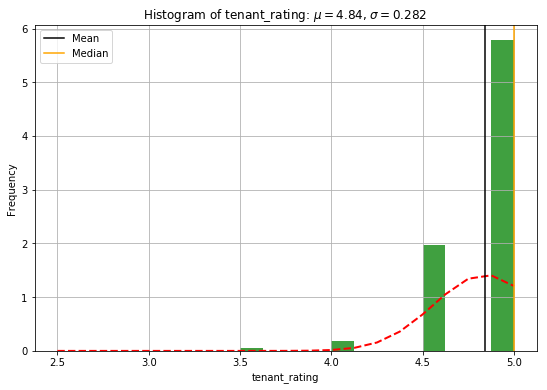

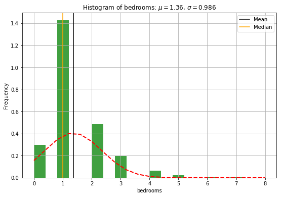

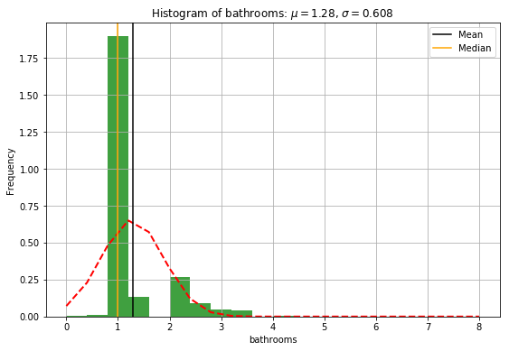

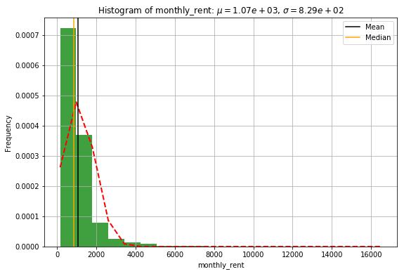

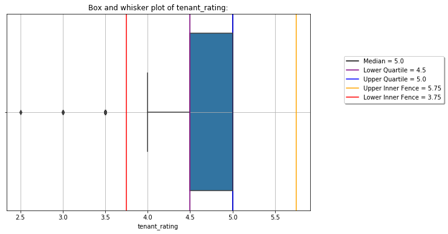

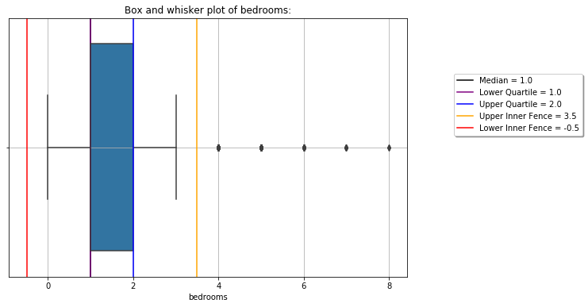

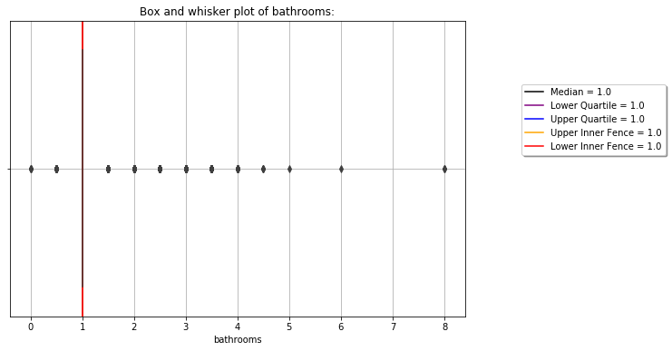

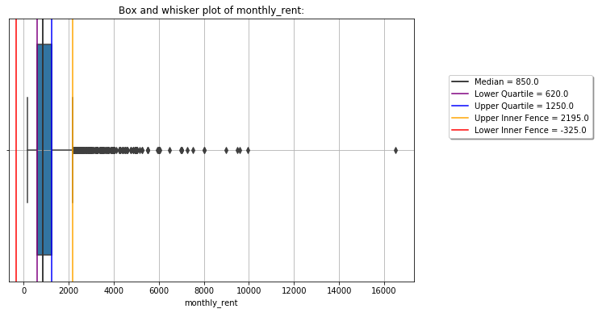

```python
# Looping through all columns and plotting a histogram with a normal curve approximated on our full dataset
# Just a proof of concept that distribution does not change
for i in list(clean_data.columns[1:]):
    fig, ax= plt.subplots()
    fig.set_size_inches(9, 6)
    plt.subplot(1,1,1)
    plot_hist(clean_data[i], i)
    plt.show()
#  Iterating through our columns and printing a boxplot for each feature
for i in list(clean_data.columns[1:]):
    fig, ax= plt.subplots()
    fig.set_size_inches(9, 6)
    plt.subplot(1,1,1)
    plot_box(clean_data, i)
    plt.show()
```

```python
# storing our continuous features in a list
cont_feats = list(clean_data.columns[1:])
```

```python
# Initialize a scaler, then apply it to the features with a default of 0 -> 1
scaler = MinMaxScaler()
# copying over our clean dataframe to store in our minmax transformed dataframe
clean_data_minmax_transform = clean_data.copy()
# Transforming our new dataframes continuous features
fitted_scaler = scaler.fit(clean_data[cont_feats[:-1]])
clean_data_minmax_transform[cont_feats[:-1]] = fitted_scaler.transform(clean_data[cont_feats[:-1]])
```

```python
# Having a quick look
clean_data_minmax_transform.head()
```

|  | listing_type | tenant_rating | bedrooms | bathrooms | monthly_rent |
| --- | --- | --- | --- | --- | --- |
| 0 | entire home/apt | 1.0 | 0.500 | 0.3125 | 2500 |
| 2 | private room | 0.8 | 0.125 | 0.1250 | 820 |
| 3 | entire home/apt | 1.0 | 0.000 | 0.1250 | 490 |
| 4 | entire home/apt | 0.8 | 0.125 | 0.1250 | 900 |
| 5 | private room | 0.8 | 0.125 | 0.3750 | 650 |

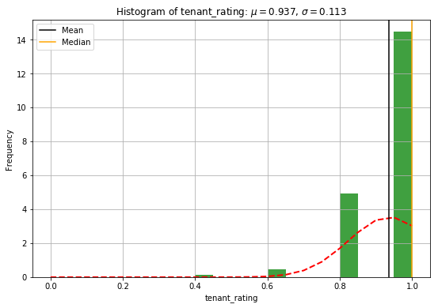

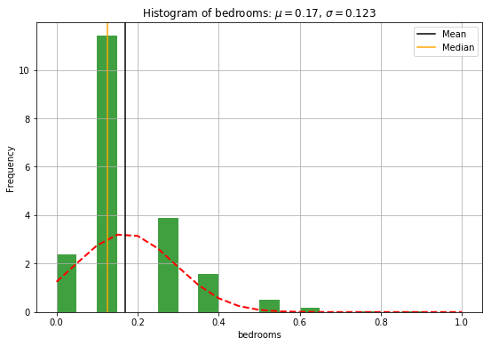

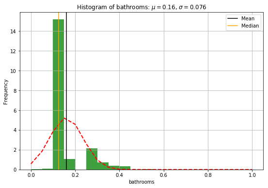

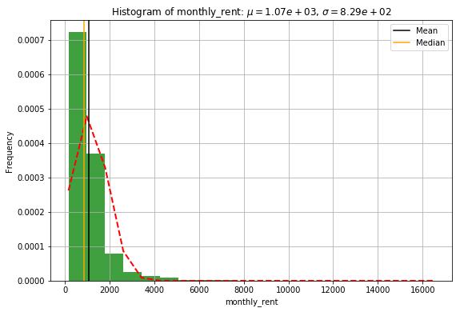

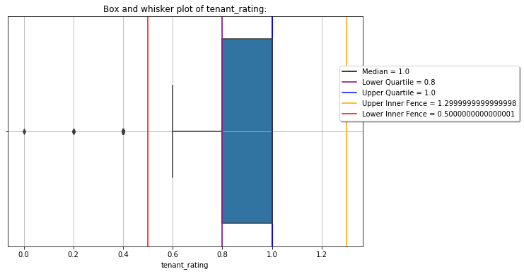

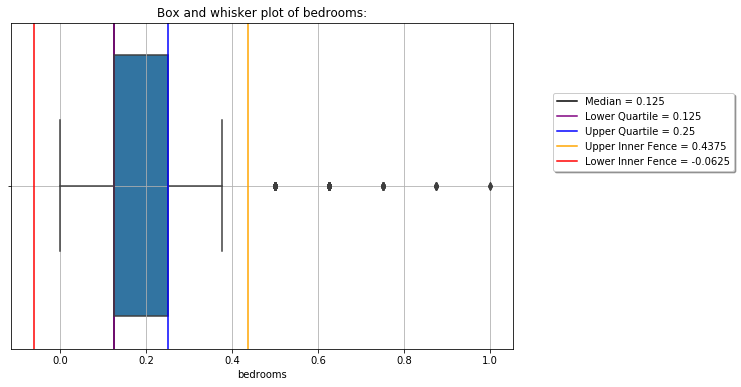

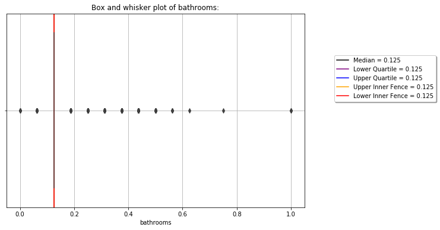

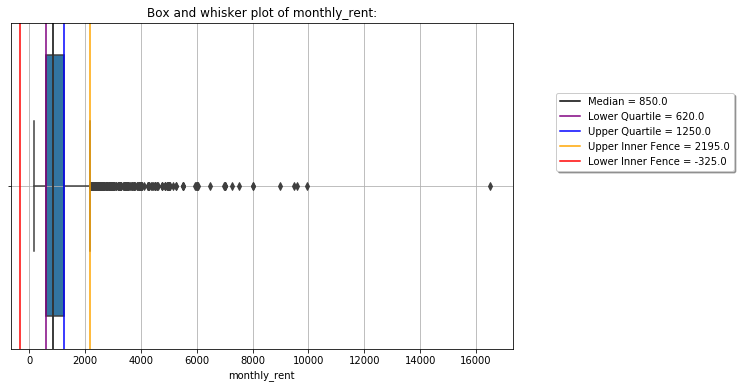

```python
# Looping through all columns and plotting a histogram with a normal curve approximated on our full dataset
# Just a proof of concept that distribution does not change
for i in cont_feats:
    fig, ax= plt.subplots()
    fig.set_size_inches(9, 6)
    plt.subplot(1,1,1)
    plot_hist(clean_data_minmax_transform[i], i)
    plt.show()
#  Iterating through our columns and printing a boxplot for each feature
for i in cont_feats:
    fig, ax= plt.subplots()
    fig.set_size_inches(9, 6)
    plt.subplot(1,1,1)
    plot_box(clean_data_minmax_transform, i)
    plt.show()
```

```python
# One-hot encode the 'clean_data_minmax_transform' data using pandas.get_dummies()
final_clean_data = pd.get_dummies(clean_data_minmax_transform)
```

```python
# Final DataFrame check!
final_clean_data.head()
```

|  | tenant_rating | bedrooms | bathrooms | monthly_rent | listing_type_entire home/apt | listing_type_private room | listing_type_shared room |
| --- | --- | --- | --- | --- | --- | --- | --- |
| 0 | 1.0 | 0.500 | 0.3125 | 2500 | 1 | 0 | 0 |
| 2 | 0.8 | 0.125 | 0.1250 | 820 | 0 | 1 | 0 |
| 3 | 1.0 | 0.000 | 0.1250 | 490 | 1 | 0 | 0 |
| 4 | 0.8 | 0.125 | 0.1250 | 900 | 1 | 0 | 0 |
| 5 | 0.8 | 0.125 | 0.3750 | 650 | 0 | 1 | 0 |

## Task 4:

### Seperating Data

Here we will:

1. Create three distinct datasets (training, testing, validation) with a 70/20/10 split.
- Print the total number of samples in each dataset
- Note: my first attempt used sklearns test-train split function. However, it seemed to have issues on the 2nd split of the testing data -> testing + validation.

```python
# 1. Randomly selecting 70% of our original dataframe
final_clean_data_train = final_clean_data.sample(frac = 0.7)
```

```python
# 1. Selecting the leftover 30% of the data to transfer into our test set
final_clean_data_test = final_clean_data.drop(final_clean_data_train.index).copy()
```

```python
# 1. Selecting 1/3rd of the test data for the validation set
final_clean_data_val = final_clean_data_test.sample(frac=0.33333)
```

```python
# 1. Removing the validation data points from the test set
final_clean_data_test.drop(final_clean_data_val.index,inplace=True)
```

```python
# 2. Displaying the size of all the sets
print('Train size: {}, Test size: {}, Validation size: {}'.format(final_clean_data_train.shape[0],
                                                                  final_clean_data_test.shape[0],
                                                                  final_clean_data_val.shape[0]))
```

```
Train size: 4271, Test size: 1220, Validation size: 610
```

```python
# Checking we have the right shape train,test and validation data sets
assert round(final_clean_data_train.shape[0]/final_clean_data.shape[0],2) == 0.7
assert round(final_clean_data_test.shape[0]/final_clean_data.shape[0],2) == 0.2
assert round(final_clean_data_val.shape[0]/final_clean_data.shape[0],2) == 0.1
print("If we are seeing this it means we have successfully created our training, testing and validation sets!")
```

```
If we are seeing this it means we have successfully created our training, testing and validation sets!
```

```python
# Resetting the indecies for all datasets
final_clean_data_train.reset_index(drop=True,inplace=True)
final_clean_data_test.reset_index(drop=True,inplace=True)
final_clean_data_val.reset_index(drop=True,inplace=True)
```

```python
# Splitting into target and feature variables for training data
y_train = final_clean_data_train['monthly_rent'].copy()
X_train = final_clean_data_train.drop('monthly_rent', axis=1).copy()

# Splitting into target and feature variables for testing data
y_test = final_clean_data_test['monthly_rent'].copy()
X_test = final_clean_data_test.drop('monthly_rent', axis=1).copy()

# Splitting into target and feature variables for validation data
y_val = final_clean_data_val['monthly_rent'].copy()
X_val = final_clean_data_val.drop('monthly_rent', axis=1).copy()
```

```python
# Quick look at one of our Inputs sets
X_val.head()
```

|  | tenant_rating | bedrooms | bathrooms | listing_type_entire home/apt | listing_type_private room | listing_type_shared room |
| --- | --- | --- | --- | --- | --- | --- |
| 0 | 1.0 | 0.250 | 0.250 | 1 | 0 | 0 |
| 1 | 1.0 | 0.375 | 0.375 | 1 | 0 | 0 |
| 2 | 1.0 | 0.125 | 0.125 | 0 | 1 | 0 |
| 3 | 1.0 | 0.125 | 0.125 | 1 | 0 | 0 |
| 4 | 1.0 | 0.000 | 0.125 | 1 | 0 | 0 |

```python
# Pipelining the cleaning process from task 3:
def cleaning_data(clean_data, cont_feats):

    # Initialize a scaler, then apply it to the features with a default of 0 -> 1
    scaler = MinMaxScaler()
    # copying over our clean dataframe to store in our minmax transformed dataframe
    clean_data_minmax_transform = clean_data.copy()
    # Transforming our new dataframes continuous features
    fitted_scaler = scaler.fit(clean_data[cont_feats[:-1]])
    clean_data_minmax_transform[cont_feats[:-1]] = fitted_scaler.transform(clean_data[cont_feats[:-1]])

    # One-hot encode the 'clean_data_minmax_transform' data using pandas.get_dummies()
    final_clean_data = pd.get_dummies(clean_data_minmax_transform)

    return final_clean_data


# Pipelining the splitting processes:
def split_data(final_clean_data):

    # Randomly selecting 70% of our original dataframe
    final_clean_data_train = final_clean_data.sample(frac = 0.7)
    # Selecting the leftover 30% of the data to transfer into our test set
    final_clean_data_test = final_clean_data.drop(final_clean_data_train.index).copy()
    # Selecting 1/3rd of the test data for the validation set
    final_clean_data_val = final_clean_data_test.sample(frac=0.33333)
    # Removing the validation data points from the test set
    final_clean_data_test.drop(final_clean_data_val.index,inplace=True)

    # Resetting the indecies for all datasets
    final_clean_data_train.reset_index(drop=True,inplace=True)
    final_clean_data_test.reset_index(drop=True,inplace=True)
    final_clean_data_val.reset_index(drop=True,inplace=True)


    # Splitting into target and feature variables for training data
    y_train = final_clean_data_train['monthly_rent'].copy()
    X_train = final_clean_data_train.drop('monthly_rent', axis=1).copy()

    # Splitting into target and feature variables for testing data
    y_test = final_clean_data_test['monthly_rent'].copy()
    X_test = final_clean_data_test.drop('monthly_rent', axis=1).copy()

    # Splitting into target and feature variables for validation data
    y_val = final_clean_data_val['monthly_rent'].copy()
    X_val = final_clean_data_val.drop('monthly_rent', axis=1).copy()

    return y_train,X_train,y_test,X_test,y_val,X_val
```